# Background

Janek

2026-03-28

```r
playlist <- read_csv("~/Desktop/UvA/computational_musicology/groove_analysis/IDWTGTEE/I_Don't_Want_This_Groove_to_Ever_End.csv")
playlist |>
  summarise(
    mean_speechiness = mean(Speechiness),
    mean_acousticness = mean(Acousticness),
    mean_liveness = mean(Liveness),
    sd_speechiness = sd(Speechiness),
    sd_acousticness = sd(Acousticness),
    sd_liveness = sd(Liveness),
    median_speechiness = median(Speechiness),
    median_acousticness = median(Acousticness),
    median_liveness = median(Liveness),
    mad_speechiness = mad(Speechiness),
    mad_acousticness = mad(Acousticness),
    mad_liveness = mad(Liveness)
  )
```

```
## # A tibble: 1 × 12
##   mean_speechiness mean_acousticness mean_liveness sd_speechiness
##              <dbl>             <dbl>         <dbl>          <dbl>
## 1           0.0808             0.162         0.156         0.0621
## # ℹ 8 more variables: sd_acousticness <dbl>, sd_liveness <dbl>,
## #   median_speechiness <dbl>, median_acousticness <dbl>, median_liveness <dbl>,
## #   mad_speechiness <dbl>, mad_acousticness <dbl>, mad_liveness <dbl>
```

After having loaded the playlist, I will compute the transition distance across all features. This will allow me to check for spikes along the playlist length to see which moments or tracks have the least smooth transitions so that I can focus on those.

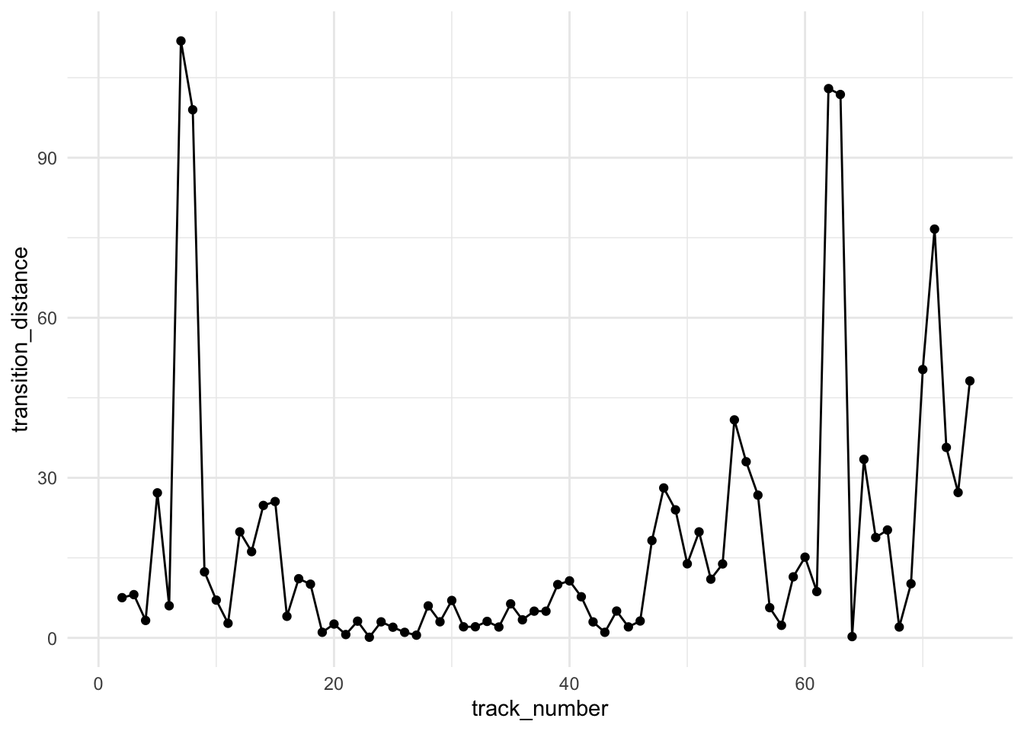

```r
# compute transition distance
playlist <- playlist %>%
  mutate(
    d_energy = Energy - lag(Energy),
    d_valence = Valence - lag(Valence),
    d_tempo = Tempo - lag(Tempo),
    d_dance = Danceability - lag(Danceability)
  )

playlist <- playlist %>%
  mutate(
    transition_distance = sqrt(
      d_energy^2 + d_valence^2 + d_tempo^2 + d_dance^2
    )
  )

ggplot(playlist, aes(x = track_number, y = transition_distance)) +
  geom_line() +
  geom_point() +
  theme_minimal()
```

To be sure that my ordering of the track influenced the Spotify track level features of the playlist at all, I will compare the mean multivariate distance of both my playlist and the same songs from it ordered in a random way.

```r
# check against randomness

set.seed(123)

random_distances <- replicate(100, {
  shuffled <- playlist %>% sample_frac(1)

  d_energy <- diff(shuffled$Energy)
  d_valence <- diff(shuffled$Valence)
  d_tempo  <- diff(shuffled$Tempo)
  d_dance  <- diff(shuffled$Danceability)

  mean(sqrt(d_energy^2 + d_valence^2 + d_tempo^2 + d_dance^2))
})

mean_original <- mean(playlist$transition_distance, na.rm = TRUE)

mean_original
```

```
## [1] 17.79647
```

```r
mean(random_distances)
```

```
## [1] 19.45647
```

This shows that my ordering did indeed influence the Spotify track level features positively, as expected. The mean multivariate distance between tracks is lower in my playlist than in a randomly ordered one.

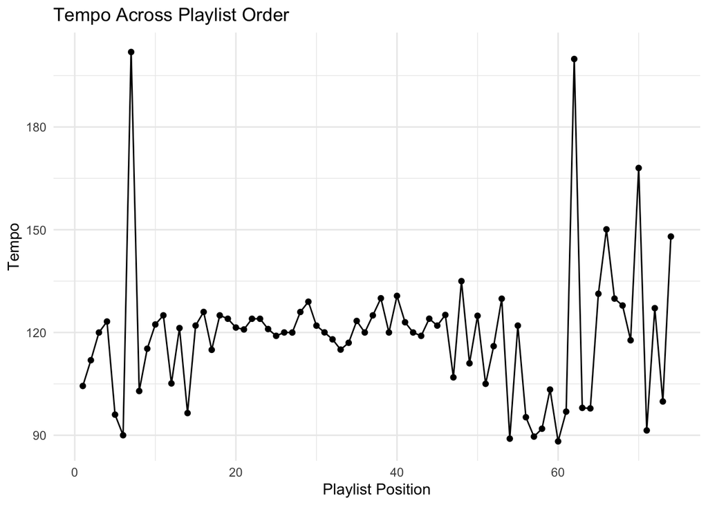

```r
ggplot(playlist, aes(x = track_number, y = Tempo)) +
  geom_line() +
  geom_point() +
  labs(
    title = "Tempo Across Playlist Order",
    x = "Playlist Position",
    y = "Tempo"
  ) +
  theme_minimal()
```

```r
library(dplyr)

playlist <- playlist %>%
  mutate(Tempo = if_else(
    track_number %in% c(7, 62),
    Tempo / 2,
    Tempo
  ))


playlist %>%
  filter(track_number %in% c(7, 62)) %>%
  select(track_number, Tempo)
```

```
## # A tibble: 2 × 2
##   track_number Tempo
##          <int> <dbl>
## 1            7 101.
## 2           62  99.9
```

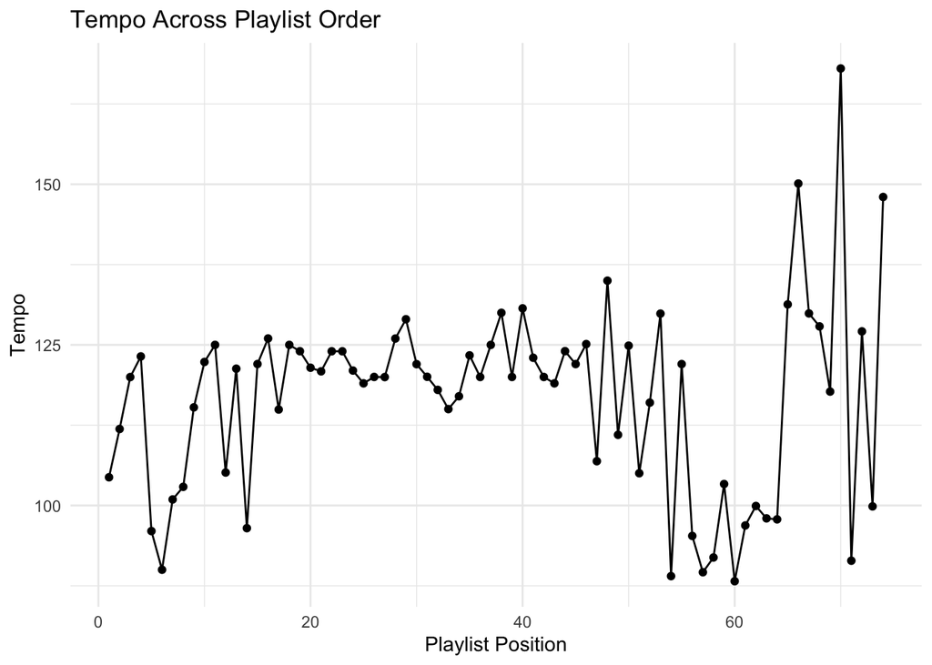

```r
ggplot(playlist, aes(x = track_number, y = Tempo)) +
  geom_line() +
  geom_point() +
  labs(
    title = "Tempo Across Playlist Order",
    x = "Playlist Position",
    y = "Tempo"
  ) +
  theme_minimal()
```

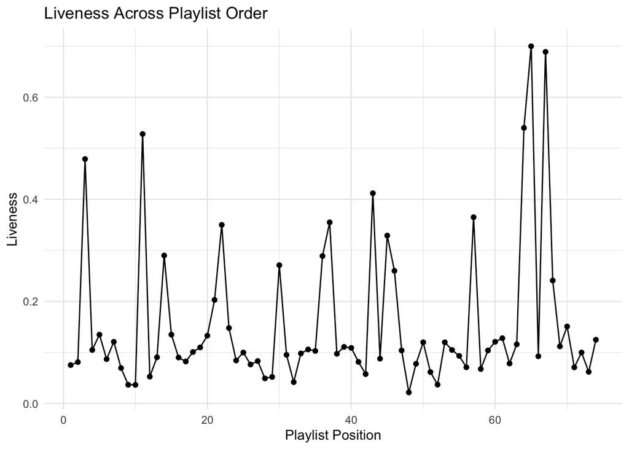

```r
ggplot(playlist, aes(x = track_number, y = Liveness)) +
  geom_line() +
  geom_point() +
  labs(
    title = "Liveness Across Playlist Order",
    x = "Playlist Position",
    y = "Liveness"
  ) +
  theme_minimal()
```

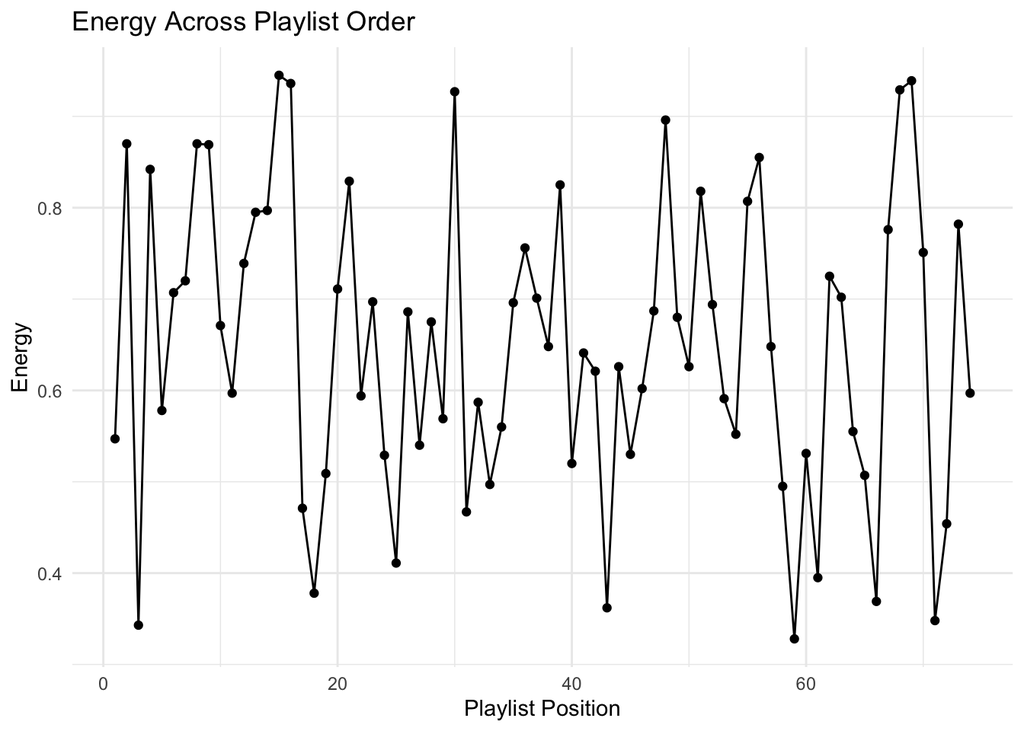

```r
ggplot(playlist, aes(x = track_number, y = Energy)) +
  geom_line() +
  geom_point() +
  labs(
    title = "Energy Across Playlist Order",
    x = "Playlist Position",
    y = "Energy"
  ) +
  theme_minimal()
```

```r
features <- playlist %>%
  select(Energy, Valence, Danceability, Tempo, Acousticness)

features_scaled <- scale(features)
```

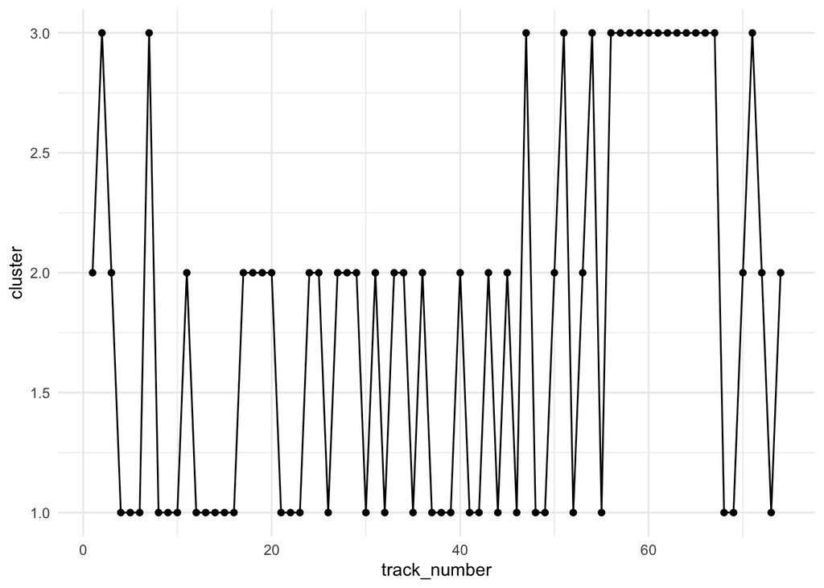

```r
# 3 clusters
set.seed(12)

kmeans_result <- kmeans(features_scaled, centers = 3, nstart = 25)

playlist$cluster <- kmeans_result$cluster

ggplot(playlist, aes(x = track_number, y = cluster)) +
  geom_point() +
  geom_line() +
  theme_minimal()
```

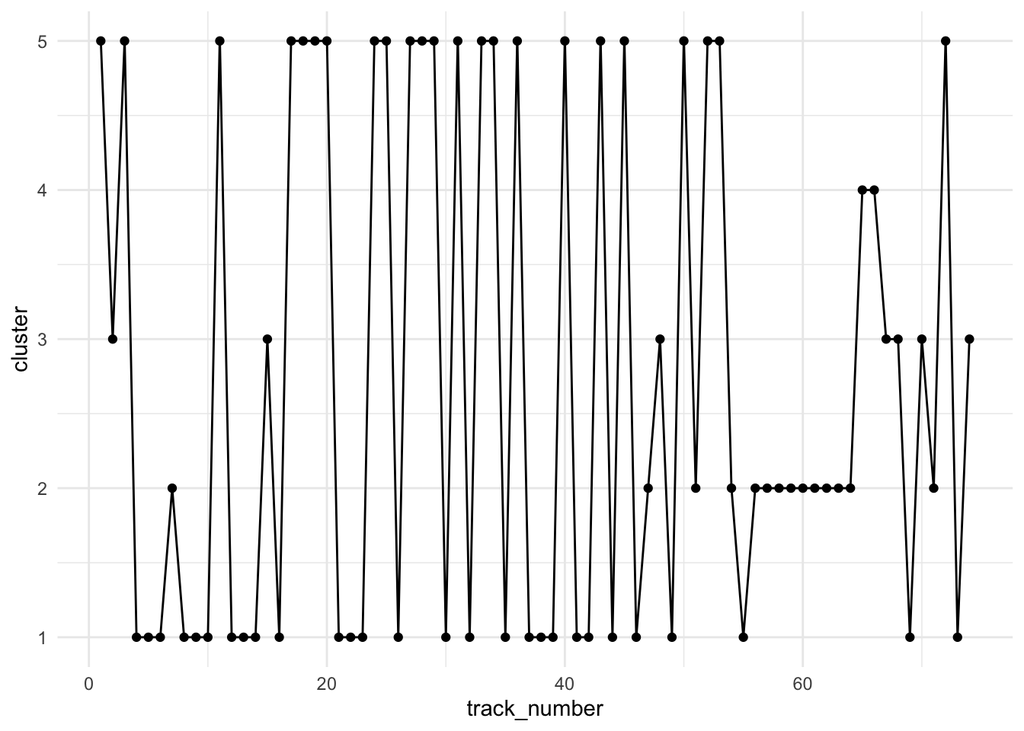

```r
# 5 clusters
set.seed(13)

kmeans_result <- kmeans(features_scaled, centers = 5, nstart = 25)

playlist$cluster <- kmeans_result$cluster

ggplot(playlist, aes(x = track_number, y = cluster)) +
  geom_point() +
  geom_line() +
  theme_minimal()
```

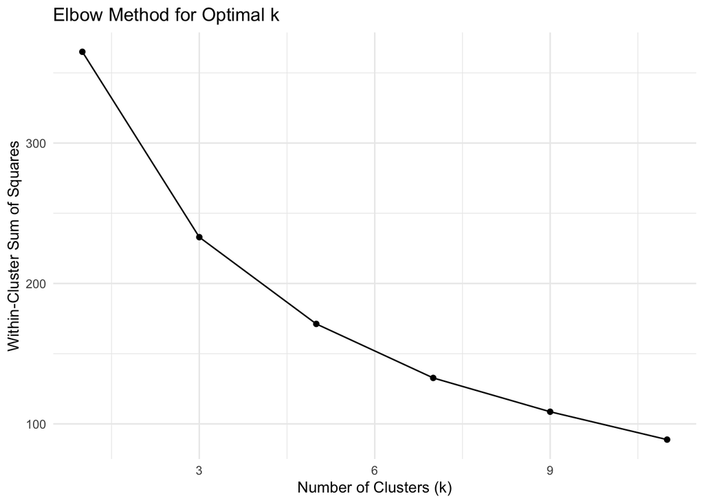

```r
# check optimal number of clusters

set.seed(123)

wss <- sapply(seq(1, 11, by = 2), function(k) {
  kmeans(features_scaled, centers = k, nstart = 25)$tot.withinss
})

elbow_df <- data.frame(
  k = seq(1, 11, by = 2),
  wss = wss
)

ggplot(elbow_df, aes(x = k, y = wss)) +
  geom_line() +
  geom_point() +
  labs(
    title = "Elbow Method for Optimal k",
    x = "Number of Clusters (k)",
    y = "Within-Cluster Sum of Squares"
  ) +
  theme_minimal()
```